# AE-04: Flights - data wrangling II

submit at end of class (exit ticket)

Author

SOLUTIONS

Published

September 23, 2024

We will again work with data from the `nycflights13` package.

```r
library(nycflights13)
library(tidyverse)
```

## Exercise 1

Examine the documentation for the datasets `airports`, `flights`, and `planes`. What are the dimensions of each? How are these datasets related?

> `flights` contains all the on-time/delay data for all flights that departed NYC in 2013. `airports` contains additional metadata about the airports, such as latitude, longitude, time zone, etc. The `faa` code in `airports` matches the `dest` and `origin` codes in `flights` . `planes` contains additional metadata for all the plane tailnumbers in the FAA registry. These can be linked to `tailnum` in `flights`.

```r
dim(flights)
```

```
[1] 336776     19
```

```r
dim(airports)
```

```
[1] 1458    8
```

```r
dim(planes)
```

```
[1] 3322    9
```

Suppose you wanted to make a map of the route of every flight. What variables would you need from which datasets? You need the geographic location of the airports (from `airports`) and the path of flights (i.e., which airports were involved) from `flights`.

We want to join flights to airports. Note these two datasets have no variables in common so we will have to specify the variable to join by using by =. Check out the documentation for more information.

```r
flights %>%
  left_join(airports, by = c("dest" = "faa"))
```

```
# A tibble: 336,776 × 26
    year month   day dep_time sched_dep_time dep_delay arr_time sched_arr_time
   <int> <int> <int>    <int>          <int>     <dbl>    <int>          <int>
 1  2013     1     1      517            515         2      830            819
 2  2013     1     1      533            529         4      850            830
 3  2013     1     1      542            540         2      923            850
 4  2013     1     1      544            545        -1     1004           1022
 5  2013     1     1      554            600        -6      812            837
 6  2013     1     1      554            558        -4      740            728
 7  2013     1     1      555            600        -5      913            854
 8  2013     1     1      557            600        -3      709            723
 9  2013     1     1      557            600        -3      838            846
10  2013     1     1      558            600        -2      753            745
# ℹ 336,766 more rows
# ℹ 18 more variables: arr_delay <dbl>, carrier <chr>, flight <int>,
#   tailnum <chr>, origin <chr>, dest <chr>, air_time <dbl>, distance <dbl>,
#   hour <dbl>, minute <dbl>, time_hour <dttm>, name <chr>, lat <dbl>,
#   lon <dbl>, alt <dbl>, tz <dbl>, dst <chr>, tzone <chr>
```

## Exercise 2

Create a new dataset `dest_delays` with the median arrival delay for each destination. *Note this question does not require you to use joins.*

```r
dest_delays <- flights %>%
  group_by(dest) %>%
  summarize(median_delay = median(arr_delay, na.rm = TRUE))
dest_delays
```

```
# A tibble: 105 × 2
   dest  median_delay
   <chr>        <dbl>
 1 ABQ           -5.5
 2 ACK           -3
 3 ALB           -4
 4 ANC            1.5
 5 ATL           -1
 6 AUS           -5
 7 AVL           -1
 8 BDL          -10
 9 BGR           -9
10 BHM           -2
# ℹ 95 more rows
```

## Exercise 3

Create a new dataset by joining `dest_delays` and `airports`. Only include observations that have both delay and airport information. *Note `dest_delays` and `flights` have no variables in common so you will need to specify the variables to join using by as in the example above.*

```r
airport_with_delays <- dest_delays %>%
  inner_join(airports, by = c("dest" = "faa"))
```

## Exercise 4

Are all of the rows in `dest_delays` included in the new dataset you created by joining `dest_delays` and `airports`? Use an `anti_join` to help investigate this issue. Recall `anti_join(x,y)` returns all rows from `x` without a match in `y`.

```r
anti_join(dest_delays, airport_with_delays)
```

```
# A tibble: 4 × 2
  dest  median_delay
  <chr>        <dbl>
1 BQN             -1
2 PSE              0
3 SJU             -6
4 STT             -9
```

Where are the above airports are located? *Hint: Google them*

> The airports not included are located in Puerto Rico and the Virgin Islands

## Exercise 5

Is there a relationship between the age of a plane and its delays? The plane tail number is given in the `tailnum` variable in the `flights` dataset. The year the plane was manufactured is given in the `year` variable in the `planes` dataset.

Start by finding the average arrival delay for each plane and store the resulting dataset in `plane_delays`.

```r
plane_delays <- flights %>%
  group_by(tailnum) %>%
  summarize(avg_arr_delay = mean(arr_delay, na.rm = TRUE))
```

Join `plane_delays` to the planes data using an appropriate join and then use `mutate` to create an `age` variable. Note this data is from 2013.

```r
planes <- nycflights13::planes %>%
  left_join(plane_delays) %>%
  mutate(age = 2013 - year)
```

Finally, create an effective visualization of the data to investigate if there a relationship between the age of a plane and its delays. Comment on your conclusions.

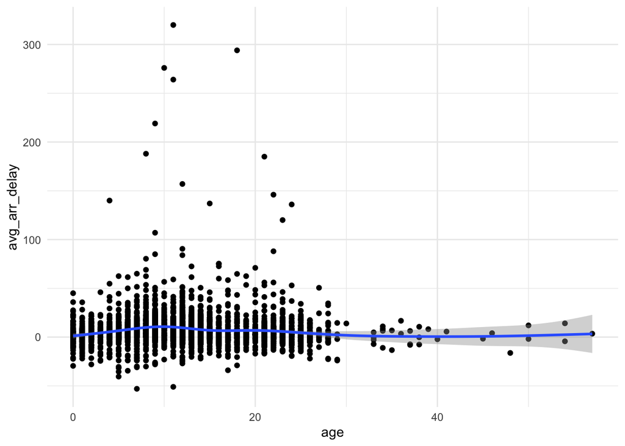

```r
ggplot(planes, aes(x = age, y = avg_arr_delay)) +
  geom_point() +
  geom_smooth() +
  theme_minimal()
```

## BONUS / Extra mapping fun

Try re-creating the visualization below and/or exploring other ways to visualized the flights data spatially.

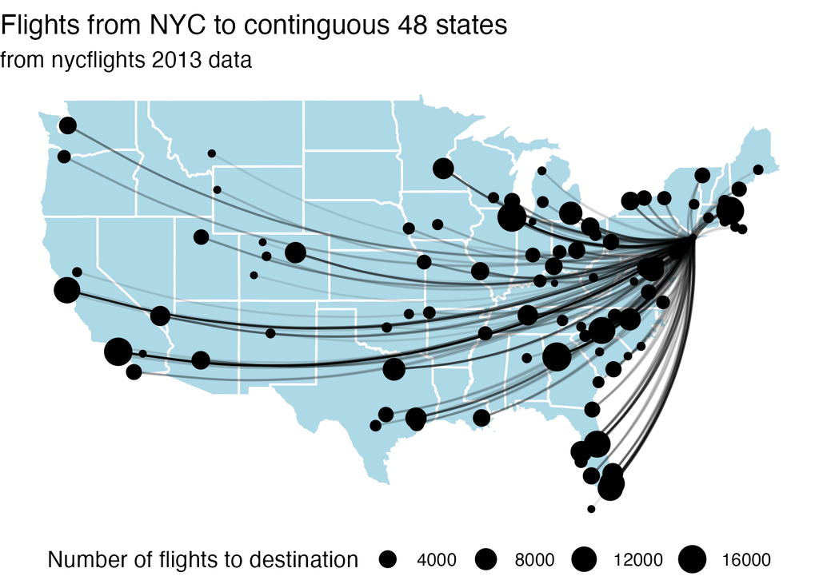

Some starter code is provided below for creating a basic US map.

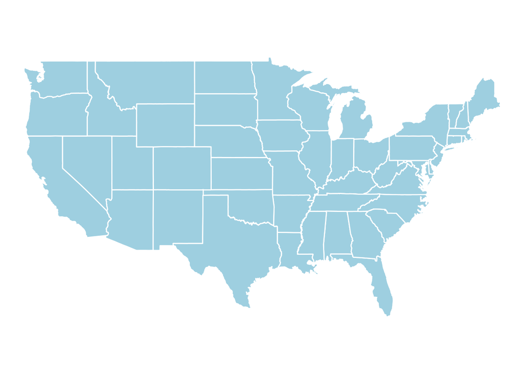

```r
library(maps)
library(mapdata)

state <- map_data("state")

ggplot() +
  geom_polygon(data = state,
               aes(x = long, y = lat, group = group),
               fill = 'lightblue', color = "white") +
  theme_void() +
  coord_fixed(1.3)
```

Adding on the flight trajectories will require some creative data wrangling. Hint: you will need a dataframe with at least 7 columns: the ID, latitude, and longitude for both the origin and destination airports, and a count column of the number of flights between those dest-origin airports. You can use a `geom_curve()` layer to create the flight curves; the above plot has `curvature = 0.2`.

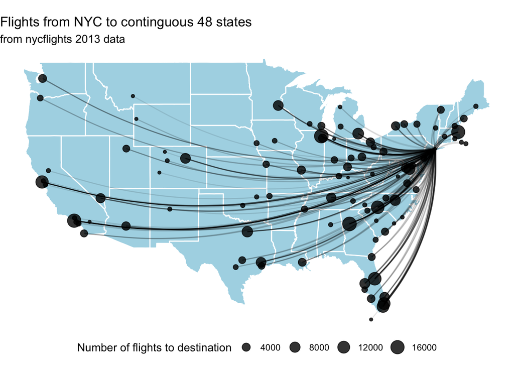

```r
#create data frame of airports, with dest_delay info
#but keep only the "lower 48" states
#that is, exclude Hawaii and Alaska for plotting purposes
#this can be accomplished by removing timezones
airports_US48 <- airports %>%
  inner_join(dest_delays, by = c("faa" ="dest")) %>%
  filter(!(tz %in% c(8, -9, -10)))

#count the number of flights that go to each destination
dest_freq <- flights %>%
  count(dest)

#add that variable to airports_US48
airports_US48 <- airports_US48 %>%
  left_join(dest_freq, by = c("faa" = "dest"))

#create data frame with longitude/latitude info
#for the three origin airports
orig_locations <- airports %>%
  filter(faa %in% c("EWR", "JFK", "LGA")) %>%
  select(faa, lat, lon)

#add longitude/latitude info of airports for each flight
#use suffix in join function to indicate whether long/lat
#column is for the origin or destination airport
# flights <- flights %>%
#   left_join(airports, by = c("dest" = "faa")) %>%
#   left_join(orig_locations, by = c("origin" = "faa"),
#             suffix = c(".dest", ".orig"))

#count the number of times each flight path occurs
#join longitude/latitude info of airports
#use suffix in join function to indicate whether long/lat
#column is for the origin or destination airport
path_count <- flights %>%
  count(dest, origin) %>%
  inner_join(airports_US48 %>% select(-n),
             by = c("dest" = "faa")) %>%
  inner_join(orig_locations, by = c("origin" = "faa"),
            suffix = c(".dest", ".orig"))


ggplot() +
  #creates base layer of lightblue state map
  geom_polygon(data = state,
               aes(x = long, y = lat, group = group),
               fill = 'lightblue', color = "white") +
  #add points for each airport location, size mapped to
  #number of flights that travel to that destination
  geom_point(data = airports_US48, aes(x = lon, y = lat,
                                       size = n), alpha = 0.8) +
  #add flight paths, transparency mapped to number of flights
  #that followed that origin-dest path
  geom_curve(data = path_count, aes(x = lon.dest,
                                    y = lat.dest,
                                    xend = lon.orig,
                                    yend = lat.orig,
                                    alpha = n),
             curvature = .2) +
  theme_void() +
  coord_fixed(1.3) +
  guides(alpha = "none") +
  labs(title = "Flights from NYC to continguous 48 states",
       subtitle = "from nycflights 2013 data",
       size = "Number of flights to destination") +
  theme(legend.position = "bottom")
```